# Reproducible S&P 500 DCA Timing Study

This notebook is a cleaner successor to `Project_DCA.ipynb`. It keeps the original question: **does the timing of a monthly S&P 500 DCA purchase matter?**

It also adds a robustness check: instead of only starting in January 1980, we rerun the study from 10 random start dates between 1980 and 1999, using `seed = 42`, and ask whether the same conclusions survive.

## 1. Purpose and Data Provenance

The original notebook compared several dollar-cost-averaging schedules for the S&P 500:

- buying on a specific calendar day each month
- buying on a specific weekday/week-of-month pattern
- buying when price crosses a moving average

This version runs only from local CSV snapshots committed with the repo:

- `sp500_history_1.csv`, `sp500_history_2.csv`, `sp500_history_3.csv`
- `inflation1980.csv`

The intended upstream sources were Investing.com for S&P 500 history and in2013dollars.com for the inflation table. The study uses the inflation-adjusted equivalent of `$100` in 1980 as each month's contribution. It excludes dividends, taxes, transaction costs, slippage, and reinvestment.

```python
from pathlib import Path
import calendar
import itertools
import warnings

import numpy as np
import pandas as pd
import matplotlib.pyplot as plt
from IPython.display import display

warnings.filterwarnings("ignore", category=FutureWarning)

try:
    plt.style.use("seaborn-v0_8-whitegrid")
except OSError:
    plt.style.use("default")

pd.set_option("display.precision", 4)
pd.set_option("display.max_columns", 30)

DATA_DIR = Path(".")
MARKET_FILES = [
    DATA_DIR / "sp500_history_1.csv",
    DATA_DIR / "sp500_history_2.csv",
    DATA_DIR / "sp500_history_3.csv",
]
INFLATION_FILE = DATA_DIR / "inflation1980.csv"

DATA_START = pd.Timestamp("1980-01-01")
DATA_END = pd.Timestamp("2022-12-30")
CV_RANDOM_START_MIN = pd.Timestamp("1980-01-01")
CV_RANDOM_START_MAX = pd.Timestamp("1999-12-31")
CV_SEED = 42
CV_FOLDS = 10

DAY_NAMES = ["Monday", "Tuesday", "Wednesday", "Thursday", "Friday"]
WEEK_NAMES = {1: "1st", 2: "2nd", 3: "3rd", 4: "4th"}
```

## 2. Load, Clean, Validate

```python
def clean_number(series):
    return pd.to_numeric(
        series.astype(str)
        .str.replace(",", "", regex=False)
        .str.replace("$", "", regex=False)
        .str.replace("%", "", regex=False)
        .str.strip(),
        errors="coerce",
    )


def load_market_data(files):
    missing = [str(path) for path in files if not path.exists()]
    assert not missing, f"Missing market CSV files: {missing}"

    raw = pd.concat([pd.read_csv(path) for path in files], ignore_index=True)
    required = {"日期", "收盘", "开盘", "高", "低", "交易量", "涨跌幅"}
    assert required.issubset(raw.columns), f"Missing columns: {required - set(raw.columns)}"

    market = raw.rename(
        columns={
            "日期": "Date",
            "收盘": "Close",
            "开盘": "Open",
            "高": "High",
            "低": "Low",
            "交易量": "Volume",
            "涨跌幅": "ChangePct",
        }
    ).copy()

    market["Date"] = pd.to_datetime(market["Date"])
    for col in ["Close", "Open", "High", "Low", "ChangePct"]:
        market[col] = clean_number(market[col])

    market = market.sort_values("Date").drop_duplicates("Date", keep="last")
    market = market.loc[market["Date"].between(DATA_START, DATA_END)].copy()
    market = market.set_index("Date", drop=False)

    assert not market.empty, "Market data is empty after date filtering."
    assert market.index.is_unique, "Market dates must be unique."
    assert market.index.min() == DATA_START, f"Expected first date {DATA_START.date()}, got {market.index.min().date()}"
    assert market.index.max() == DATA_END, f"Expected final date {DATA_END.date()}, got {market.index.max().date()}"
    assert market[["Close", "Open", "High", "Low"]].notna().all().all(), "Price columns contain nulls."

    market["Year"] = market.index.year
    market["YearMonth"] = market.index.to_period("M")
    market["DayOfWeek"] = market.index.weekday
    market["DayOfMonth"] = market.index.day
    market["MA30"] = market["Close"].rolling(30, min_periods=30).mean()
    market["CrossBelowMA30"] = (market["Close"].shift(1) >= market["MA30"].shift(1)) & (market["Close"] < market["MA30"])
    market["CrossAboveMA30"] = (market["Close"].shift(1) < market["MA30"].shift(1)) & (market["Close"] >= market["MA30"])
    return market


def load_inflation_data(path):
    assert path.exists(), f"Missing inflation CSV file: {path}"
    inflation = pd.read_csv(path)
    required = {"Year", "Dollar Value", "Inflation Rate"}
    assert required.issubset(inflation.columns), f"Missing columns: {required - set(inflation.columns)}"

    inflation = inflation.copy()
    inflation["Year"] = inflation["Year"].astype(int)
    inflation["MonthlyBudget"] = clean_number(inflation["Dollar Value"])
    inflation["InflationRatePct"] = clean_number(inflation["Inflation Rate"])
    assert inflation["MonthlyBudget"].notna().all(), "Inflation dollar values contain nulls."
    return inflation[["Year", "MonthlyBudget", "InflationRatePct", "Dollar Value", "Inflation Rate"]]


def attach_monthly_budget(market, inflation):
    simulation = market.merge(inflation[["Year", "MonthlyBudget"]], on="Year", how="left", validate="many_to_one")
    simulation = simulation.set_index("Date", drop=False)
    missing_years = sorted(simulation.loc[simulation["MonthlyBudget"].isna(), "Year"].unique())
    assert not missing_years, f"Missing inflation budget years: {missing_years}"
    return simulation


market = load_market_data(MARKET_FILES)
inflation = load_inflation_data(INFLATION_FILE)
simulation = attach_monthly_budget(market, inflation)
FINAL_CLOSE = float(simulation.loc[DATA_END, "Close"])

print(f"Market rows: {len(market):,}")
print(f"Market range: {market.index.min().date()} to {market.index.max().date()}")
print(f"Final valuation close on {DATA_END.date()}: {FINAL_CLOSE:,.2f}")
print(f"Inflation years: {inflation['Year'].min()} to {inflation['Year'].max()}")

display(simulation[["Close", "Open", "High", "Low", "MonthlyBudget", "MA30", "CrossBelowMA30"]].head())
display(simulation[["Close", "Open", "High", "Low", "MonthlyBudget", "MA30", "CrossBelowMA30"]].tail())
```

```
Market rows: 10,844
Market range: 1980-01-01 to 2022-12-30
Final valuation close on 2022-12-30: 3,839.50
Inflation years: 1980 to 2023
```

| Date | Close | Open | High | Low | MonthlyBudget | MA30 | CrossBelowMA30 |
| --- | --- | --- | --- | --- | --- | --- | --- |
| 1980-01-01 | 107.94 | 107.94 | 107.94 | 107.94 | 100.0 | NaN | False |
| 1980-01-02 | 105.76 | 107.94 | 108.43 | 105.29 | 100.0 | NaN | False |
| 1980-01-03 | 105.22 | 105.76 | 106.08 | 103.26 | 100.0 | NaN | False |
| 1980-01-04 | 106.52 | 105.22 | 107.08 | 105.09 | 100.0 | NaN | False |
| 1980-01-07 | 106.81 | 106.52 | 107.80 | 105.80 | 100.0 | NaN | False |

| Date | Close | Open | High | Low | MonthlyBudget | MA30 | CrossBelowMA30 |
| --- | --- | --- | --- | --- | --- | --- | --- |
| 2022-12-23 | 3844.82 | 3815.11 | 3845.80 | 3797.01 | 355.16 | 3955.9977 | False |
| 2022-12-27 | 3829.25 | 3843.34 | 3846.65 | 3813.22 | 355.16 | 3950.5417 | False |
| 2022-12-28 | 3783.22 | 3829.56 | 3848.32 | 3780.78 | 355.16 | 3944.7407 | False |
| 2022-12-29 | 3849.28 | 3805.45 | 3858.19 | 3805.45 | 355.16 | 3939.9923 | False |
| 2022-12-30 | 3839.50 | 3829.06 | 3839.85 | 3800.34 | 355.16 | 3936.0160 | False |

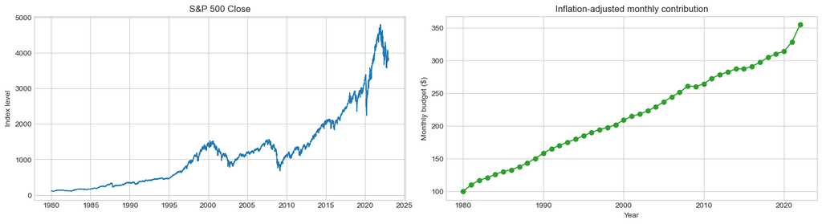

```python
fig, axes = plt.subplots(1, 2, figsize=(15, 4), constrained_layout=True)

axes[0].plot(simulation.index, simulation["Close"], color="#1f77b4", lw=1.2)
axes[0].set_title("S&P 500 Close")
axes[0].set_ylabel("Index level")

annual_budget = inflation.loc[inflation["Year"].between(DATA_START.year, DATA_END.year)]
axes[1].plot(annual_budget["Year"], annual_budget["MonthlyBudget"], marker="o", color="#2ca02c", lw=1.5)
axes[1].set_title("Inflation-adjusted monthly contribution")
axes[1].set_ylabel("Monthly budget ($)")
axes[1].set_xlabel("Year")

plt.show()
```

## 3. Helper Functions

```python
def first_full_following_month(date):
    date = pd.Timestamp(date).normalize()
    return date + pd.offsets.MonthBegin(1)


def slice_for_backtest(data, start_date, end_date=DATA_END):
    start_date = pd.Timestamp(start_date)
    sliced = data.loc[data.index.to_series().between(start_date, end_date)].copy()
    assert not sliced.empty, f"No data between {start_date.date()} and {end_date.date()}"
    assert sliced.index.max() == end_date, "Every backtest must include the shared final valuation date."
    return sliced


def month_groups(data):
    return list(data.groupby("YearMonth", sort=True))


def total_monthly_budget(data):
    return float(data.groupby("YearMonth")["MonthlyBudget"].first().sum())


def value_purchases(purchases, data, final_close=FINAL_CLOSE, cash=0.0, total_budget=None):
    purchases = purchases.copy()
    purchases["Shares"] = purchases["InvestAmount"] / purchases["BuyClose"]
    invested = float(purchases["InvestAmount"].sum())
    if total_budget is None:
        total_budget = invested
    final_value = float(purchases["Shares"].sum() * final_close + cash)
    return {
        "total_budget": float(total_budget),
        "total_invested": invested,
        "cash_remaining": float(cash),
        "final_value": final_value,
        "return_multiple": final_value / float(total_budget),
        "num_buys": int(len(purchases)),
    }, purchases


def choose_day_of_month(group, target_day):
    candidates = group.loc[group["DayOfMonth"] >= target_day]
    if candidates.empty:
        return group.iloc[-1]
    return candidates.iloc[0]


def run_day_of_month_strategy(data, target_day, label_prefix="Day"):
    rows = []
    for _, group in month_groups(data):
        row = choose_day_of_month(group, target_day)
        rows.append(
            {
                "BuyDate": row["Date"],
                "BuyClose": row["Close"],
                "InvestAmount": row["MonthlyBudget"],
                "YearMonth": row["YearMonth"],
            }
        )
    purchases = pd.DataFrame(rows)
    metrics, purchases = value_purchases(purchases, data)
    metrics.update(
        {
            "family": "day_of_month",
            "strategy_key": f"day_{target_day:02d}",
            "strategy_name": f"{label_prefix} {target_day}",
            "sort_order": target_day,
        }
    )
    return metrics, purchases


def nth_weekday_date(year, month, week_number, weekday):
    matches = [
        pd.Timestamp(year=year, month=month, day=day)
        for day in range(1, calendar.monthrange(year, month)[1] + 1)
        if pd.Timestamp(year=year, month=month, day=day).weekday() == weekday
    ]
    return matches[week_number - 1]


def choose_weekday_week(group, week_number, weekday):
    period = group["YearMonth"].iloc[0]
    target = nth_weekday_date(period.year, period.month, week_number, weekday)
    friday = target + pd.Timedelta(days=(4 - weekday))

    same_week = group.loc[(group.index >= target) & (group.index <= friday)]
    if not same_week.empty:
        return same_week.iloc[0]

    later_in_month = group.loc[group.index >= target]
    if not later_in_month.empty:
        return later_in_month.iloc[0]

    return group.iloc[-1]


def run_weekday_week_strategy(data, week_number, weekday):
    rows = []
    for _, group in month_groups(data):
        row = choose_weekday_week(group, week_number, weekday)
        rows.append(
            {
                "BuyDate": row["Date"],
                "BuyClose": row["Close"],
                "InvestAmount": row["MonthlyBudget"],
                "YearMonth": row["YearMonth"],
            }
        )
    purchases = pd.DataFrame(rows)
    metrics, purchases = value_purchases(purchases, data)
    metrics.update(
        {
            "family": "week_day",
            "strategy_key": f"week_{week_number}_day_{weekday}",
            "strategy_name": f"{WEEK_NAMES[week_number]} {DAY_NAMES[weekday]}",
            "sort_order": week_number * 10 + weekday,
            "week_number": week_number,
            "weekday": weekday,
        }
    )
    return metrics, purchases


def run_ma_cross_strategy(data, signal_col="CrossBelowMA30", label="MA30 cross below"):
    rows = []
    cash = 0.0
    total_budget = 0.0
    current_month = None

    for _, row in data.iterrows():
        if row["YearMonth"] != current_month:
            current_month = row["YearMonth"]
            cash += float(row["MonthlyBudget"])
            total_budget += float(row["MonthlyBudget"])

        if bool(row[signal_col]) and cash > 0:
            invest_amount = min(float(row["MonthlyBudget"]), cash)
            rows.append(
                {
                    "BuyDate": row["Date"],
                    "BuyClose": row["Close"],
                    "InvestAmount": invest_amount,
                    "YearMonth": row["YearMonth"],
                }
            )
            cash -= invest_amount

    purchases = pd.DataFrame(rows, columns=["BuyDate", "BuyClose", "InvestAmount", "YearMonth"])
    metrics, purchases = value_purchases(purchases, data, cash=cash, total_budget=total_budget)
    metrics.update(
        {
            "family": "moving_average",
            "strategy_key": "ma30_cross_below",
            "strategy_name": label,
            "sort_order": 999,
        }
    )
    return metrics, purchases


def run_all_strategies(data):
    metrics = []
    purchases = {}

    for day in range(1, 29):
        result, buys = run_day_of_month_strategy(data, day)
        metrics.append(result)
        purchases[result["strategy_key"]] = buys

    for week, weekday in itertools.product(range(1, 5), range(5)):
        result, buys = run_weekday_week_strategy(data, week, weekday)
        metrics.append(result)
        purchases[result["strategy_key"]] = buys

    result, buys = run_ma_cross_strategy(data)
    metrics.append(result)
    purchases[result["strategy_key"]] = buys

    results = pd.DataFrame(metrics)
    results["return_pct"] = (results["return_multiple"] - 1) * 100
    return results, purchases


def add_family_ranks(results):
    ranked = results.copy()
    ranked["rank_in_family"] = ranked.groupby("family")["return_multiple"].rank(ascending=False, method="min")
    family_sizes = ranked.groupby("family")["strategy_key"].transform("count")
    top_cut = np.ceil(family_sizes * 0.25)
    bottom_cut = family_sizes - top_cut
    ranked["rank_bucket"] = np.where(
        ranked["rank_in_family"] <= top_cut,
        "top_quartile",
        np.where(ranked["rank_in_family"] > bottom_cut, "bottom_quartile", "middle"),
    )
    return ranked


def format_result_table(df, columns=None):
    if columns is None:
        columns = ["strategy_name", "total_budget", "total_invested", "cash_remaining", "final_value", "return_multiple", "return_pct", "num_buys"]
    table = df.loc[:, columns].copy()
    for col in ["total_budget", "total_invested", "cash_remaining", "final_value"]:
        if col in table:
            table[col] = table[col].map(lambda x: f"${x:,.2f}")
    if "return_multiple" in table:
        table["return_multiple"] = table["return_multiple"].map(lambda x: f"{x:.4f}x")
    if "return_pct" in table:
        table["return_pct"] = table["return_pct"].map(lambda x: f"{x:.2f}%")
    return table
```

```python
# Sanity check for the MA30 cross-below definition.
toy = pd.DataFrame(
    {
        "Close": [10.0, 11.0, 9.0, 8.0],
        "MA30": [9.0, 10.0, 10.0, 9.0],
    }
)
toy["CrossBelowMA30"] = (toy["Close"].shift(1) >= toy["MA30"].shift(1)) & (toy["Close"] < toy["MA30"])
assert toy["CrossBelowMA30"].tolist() == [False, False, True, False]
print("MA30 cross-below helper check passed.")
```

```
MA30 cross-below helper check passed.
```

## 4. Full-Period Backtest

```python
full_data = slice_for_backtest(simulation, DATA_START, DATA_END)
full_results, full_purchases = run_all_strategies(full_data)
full_results = add_family_ranks(full_results)

assert full_results.loc[full_results["family"].eq("day_of_month"), "total_budget"].nunique() == 1
assert full_results.loc[full_results["family"].eq("week_day"), "total_budget"].nunique() == 1
assert full_results["return_multiple"].dtype.kind in "fc"

baseline = full_results.loc[full_results["strategy_key"].eq("day_01")].iloc[0]
print(f"Baseline: {baseline['strategy_name']} returned {baseline['return_multiple']:.4f}x")

display(format_result_table(full_results.query("family == 'day_of_month'").sort_values("return_multiple", ascending=False).head(5)))
display(format_result_table(full_results.query("family == 'day_of_month'").sort_values("return_multiple", ascending=True).head(5)))
```

```
Baseline: Day 1 returned 5.8658x
```

|  | strategy_name | total_budget | total_invested | cash_remaining | final_value | return_multiple | return_pct | num_buys |
| --- | --- | --- | --- | --- | --- | --- | --- | --- |
| 0 | Day 1 | $111,780.72 | $111,780.72 | $0.00 | $655,687.02 | 5.8658x | 486.58% | 516 |
| 6 | Day 7 | $111,780.72 | $111,780.72 | $0.00 | $655,496.34 | 5.8641x | 486.41% | 516 |
| 5 | Day 6 | $111,780.72 | $111,780.72 | $0.00 | $655,247.59 | 5.8619x | 486.19% | 516 |
| 8 | Day 9 | $111,780.72 | $111,780.72 | $0.00 | $655,178.18 | 5.8613x | 486.13% | 516 |
| 3 | Day 4 | $111,780.72 | $111,780.72 | $0.00 | $655,147.70 | 5.8610x | 486.10% | 516 |

|  | strategy_name | total_budget | total_invested | cash_remaining | final_value | return_multiple | return_pct | num_buys |
| --- | --- | --- | --- | --- | --- | --- | --- | --- |
| 27 | Day 28 | $111,780.72 | $111,780.72 | $0.00 | $652,619.95 | 5.8384x | 483.84% | 516 |
| 25 | Day 26 | $111,780.72 | $111,780.72 | $0.00 | $652,674.18 | 5.8389x | 483.89% | 516 |
| 26 | Day 27 | $111,780.72 | $111,780.72 | $0.00 | $652,852.70 | 5.8405x | 484.05% | 516 |
| 24 | Day 25 | $111,780.72 | $111,780.72 | $0.00 | $653,133.22 | 5.8430x | 484.30% | 516 |
| 20 | Day 21 | $111,780.72 | $111,780.72 | $0.00 | $653,274.52 | 5.8443x | 484.43% | 516 |

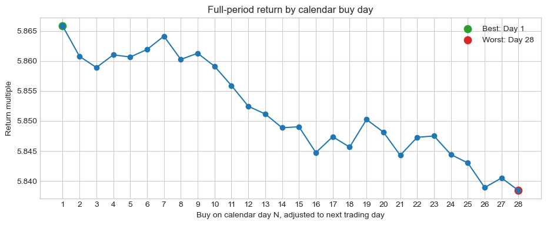

|  | strategy_name | total_budget | total_invested | cash_remaining | final_value | return_multiple | return_pct | num_buys |
| --- | --- | --- | --- | --- | --- | --- | --- | --- |
| 0 | Day 1 | $111,780.72 | $111,780.72 | $0.00 | $655,687.02 | 5.8658x | 486.58% | 516 |
| 27 | Day 28 | $111,780.72 | $111,780.72 | $0.00 | $652,619.95 | 5.8384x | 483.84% | 516 |

```python
day_results = full_results.query("family == 'day_of_month'").sort_values("sort_order")

fig, ax = plt.subplots(figsize=(11, 4))
ax.plot(day_results["sort_order"], day_results["return_multiple"], marker="o", color="#1f77b4")
best_day = day_results.loc[day_results["return_multiple"].idxmax()]
worst_day = day_results.loc[day_results["return_multiple"].idxmin()]
ax.scatter([best_day["sort_order"]], [best_day["return_multiple"]], color="#2ca02c", s=80, label=f"Best: {best_day['strategy_name']}")
ax.scatter([worst_day["sort_order"]], [worst_day["return_multiple"]], color="#d62728", s=80, label=f"Worst: {worst_day['strategy_name']}")
ax.set_title("Full-period return by calendar buy day")
ax.set_xlabel("Buy on calendar day N, adjusted to next trading day")
ax.set_ylabel("Return multiple")
ax.set_xticks(range(1, 29))
ax.legend()
plt.show()

display(format_result_table(day_results.loc[[best_day.name, worst_day.name]]))
```

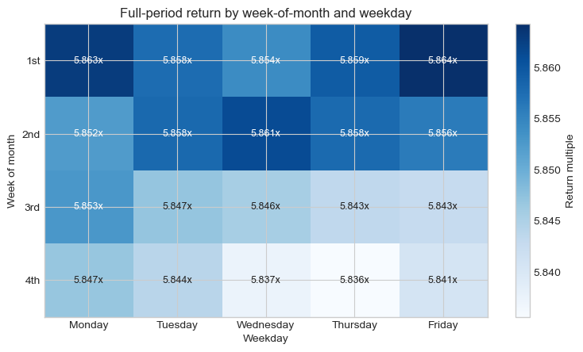

|  | strategy_name | total_budget | total_invested | cash_remaining | final_value | return_multiple | return_pct | num_buys |
| --- | --- | --- | --- | --- | --- | --- | --- | --- |
| 32 | 1st Friday | $111,780.72 | $111,780.72 | $0.00 | $655,508.04 | 5.8642x | 486.42% | 516 |
| 28 | 1st Monday | $111,780.72 | $111,780.72 | $0.00 | $655,351.64 | 5.8628x | 486.28% | 516 |
| 35 | 2nd Wednesday | $111,780.72 | $111,780.72 | $0.00 | $655,160.29 | 5.8611x | 486.11% | 516 |
| 31 | 1st Thursday | $111,780.72 | $111,780.72 | $0.00 | $654,963.22 | 5.8594x | 485.94% | 516 |
| 34 | 2nd Tuesday | $111,780.72 | $111,780.72 | $0.00 | $654,799.59 | 5.8579x | 485.79% | 516 |

|  | strategy_name | total_budget | total_invested | cash_remaining | final_value | return_multiple | return_pct | num_buys |
| --- | --- | --- | --- | --- | --- | --- | --- | --- |
| 46 | 4th Thursday | $111,780.72 | $111,780.72 | $0.00 | $652,309.70 | 5.8356x | 483.56% | 516 |
| 45 | 4th Wednesday | $111,780.72 | $111,780.72 | $0.00 | $652,497.47 | 5.8373x | 483.73% | 516 |
| 47 | 4th Friday | $111,780.72 | $111,780.72 | $0.00 | $652,869.14 | 5.8406x | 484.06% | 516 |
| 42 | 3rd Friday | $111,780.72 | $111,780.72 | $0.00 | $653,106.73 | 5.8427x | 484.27% | 516 |
| 41 | 3rd Thursday | $111,780.72 | $111,780.72 | $0.00 | $653,164.35 | 5.8433x | 484.33% | 516 |

```python
week_results = full_results.query("family == 'week_day'").copy()
heat = week_results.pivot(index="week_number", columns="weekday", values="return_multiple").sort_index()

fig, ax = plt.subplots(figsize=(9, 4.8))
im = ax.imshow(heat.values, cmap="Blues", aspect="auto")
ax.set_title("Full-period return by week-of-month and weekday")
ax.set_xlabel("Weekday")
ax.set_ylabel("Week of month")
ax.set_xticks(range(5), DAY_NAMES)
ax.set_yticks(range(4), [WEEK_NAMES[i] for i in heat.index])
for i in range(heat.shape[0]):
    for j in range(heat.shape[1]):
        text_color = "white" if heat.iloc[i, j] > heat.values.mean() else "#222222"
        ax.text(j, i, f"{heat.iloc[i, j]:.3f}x", ha="center", va="center", color=text_color, fontsize=9)
fig.colorbar(im, ax=ax, label="Return multiple")
plt.show()

display(format_result_table(week_results.sort_values("return_multiple", ascending=False).head(5)))
display(format_result_table(week_results.sort_values("return_multiple", ascending=True).head(5)))
```

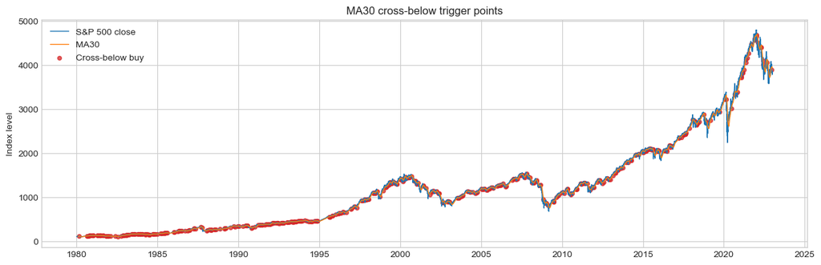

|  | strategy_name | total_budget | total_invested | cash_remaining | final_value | return_multiple | return_pct | num_buys |
| --- | --- | --- | --- | --- | --- | --- | --- | --- |
| 48 | MA30 cross below | $111,780.72 | $107,469.86 | $4,310.86 | $612,418.60 | 5.4787x | 447.87% | 495 |

```python
ma_buys = full_purchases["ma30_cross_below"]

fig, ax = plt.subplots(figsize=(15, 4.5))
ax.plot(full_data.index, full_data["Close"], color="#1f77b4", lw=1, label="S&P 500 close")
ax.plot(full_data.index, full_data["MA30"], color="#ff7f0e", lw=1, label="MA30")
ax.scatter(ma_buys["BuyDate"], ma_buys["BuyClose"], s=18, color="#d62728", alpha=0.75, label="Cross-below buy")
ax.set_title("MA30 cross-below trigger points")
ax.set_ylabel("Index level")
ax.legend(loc="upper left")
plt.show()

display(format_result_table(full_results.query("family == 'moving_average'")))
```

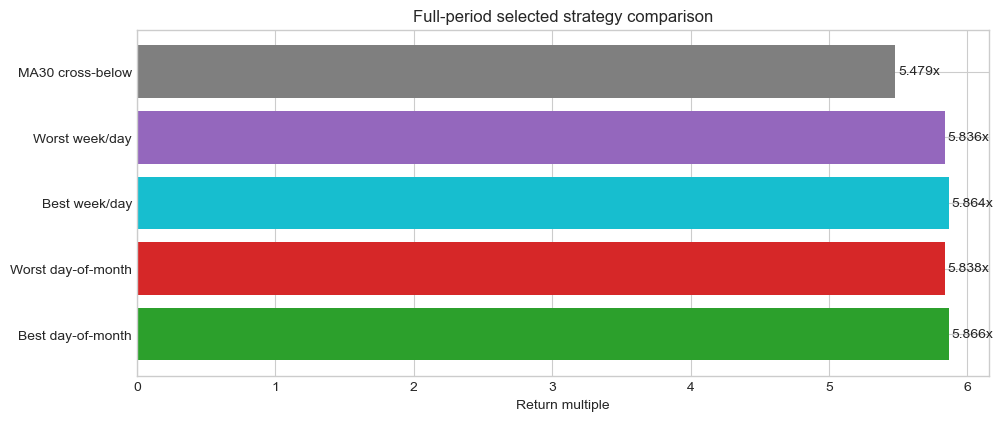

|  | comparison_label | strategy_name | family | total_budget | total_invested | cash_remaining | final_value | return_multiple | return_pct | num_buys |
| --- | --- | --- | --- | --- | --- | --- | --- | --- | --- | --- |
| 0 | Best day-of-month | Day 1 | day_of_month | $111,780.72 | $111,780.72 | $0.00 | $655,687.02 | 5.8658x | 486.58% | 516 |
| 27 | Worst day-of-month | Day 28 | day_of_month | $111,780.72 | $111,780.72 | $0.00 | $652,619.95 | 5.8384x | 483.84% | 516 |
| 32 | Best week/day | 1st Friday | week_day | $111,780.72 | $111,780.72 | $0.00 | $655,508.04 | 5.8642x | 486.42% | 516 |
| 46 | Worst week/day | 4th Thursday | week_day | $111,780.72 | $111,780.72 | $0.00 | $652,309.70 | 5.8356x | 483.56% | 516 |
| 48 | MA30 cross-below | MA30 cross below | moving_average | $111,780.72 | $107,469.86 | $4,310.86 | $612,418.60 | 5.4787x | 447.87% | 495 |

```python
def selected_comparison_rows(results):
    rows = []
    day = results.query("family == 'day_of_month'")
    week = results.query("family == 'week_day'")
    rows.extend(
        [
            day.loc[day["return_multiple"].idxmax()],
            day.loc[day["return_multiple"].idxmin()],
            week.loc[week["return_multiple"].idxmax()],
            week.loc[week["return_multiple"].idxmin()],
            results.loc[results["strategy_key"].eq("day_01")].iloc[0],
            results.loc[results["strategy_key"].eq("ma30_cross_below")].iloc[0],
        ]
    )
    comparison = pd.DataFrame(rows).drop_duplicates("strategy_key")
    comparison["comparison_label"] = [
        "Best day-of-month" if r["strategy_key"] == day.loc[day["return_multiple"].idxmax(), "strategy_key"]
        else "Worst day-of-month" if r["strategy_key"] == day.loc[day["return_multiple"].idxmin(), "strategy_key"]
        else "Best week/day" if r["strategy_key"] == week.loc[week["return_multiple"].idxmax(), "strategy_key"]
        else "Worst week/day" if r["strategy_key"] == week.loc[week["return_multiple"].idxmin(), "strategy_key"]
        else "First-trading-day baseline" if r["strategy_key"] == "day_01"
        else "MA30 cross-below"
        for _, r in comparison.iterrows()
    ]
    return comparison


comparison = selected_comparison_rows(full_results)
fig, ax = plt.subplots(figsize=(11, 4.5))
bars = ax.barh(comparison["comparison_label"], comparison["return_multiple"], color=["#2ca02c", "#d62728", "#17becf", "#9467bd", "#7f7f7f", "#ff7f0e"])
ax.set_title("Full-period selected strategy comparison")
ax.set_xlabel("Return multiple")
for bar, value in zip(bars, comparison["return_multiple"]):
    ax.text(value + 0.02, bar.get_y() + bar.get_height() / 2, f"{value:.3f}x", va="center")
plt.show()

display(format_result_table(comparison[["comparison_label", "strategy_name", "family", "total_budget", "total_invested", "cash_remaining", "final_value", "return_multiple", "return_pct", "num_buys"]], columns=["comparison_label", "strategy_name", "family", "total_budget", "total_invested", "cash_remaining", "final_value", "return_multiple", "return_pct", "num_buys"]))
```

## 5. Start-Date Robustness Validation

|  | fold | random_start_date | effective_start_date | years_to_end |
| --- | --- | --- | --- | --- |
| 0 | 1 | 1981-09-19 | 1981-10-01 | 41.2457 |
| 1 | 2 | 1981-10-13 | 1981-11-01 | 41.1608 |
| 2 | 3 | 1981-11-18 | 1981-12-01 | 41.0787 |
| 3 | 4 | 1984-01-11 | 1984-02-01 | 38.9103 |
| 4 | 5 | 1988-08-27 | 1988-09-01 | 34.3272 |
| 5 | 6 | 1988-10-08 | 1988-11-01 | 34.1602 |
| 6 | 7 | 1993-01-29 | 1993-02-01 | 29.9083 |
| 7 | 8 | 1993-12-10 | 1994-01-01 | 28.9938 |
| 8 | 9 | 1995-06-18 | 1995-07-01 | 27.4990 |
| 9 | 10 | 1997-02-28 | 1997-03-01 | 25.8316 |

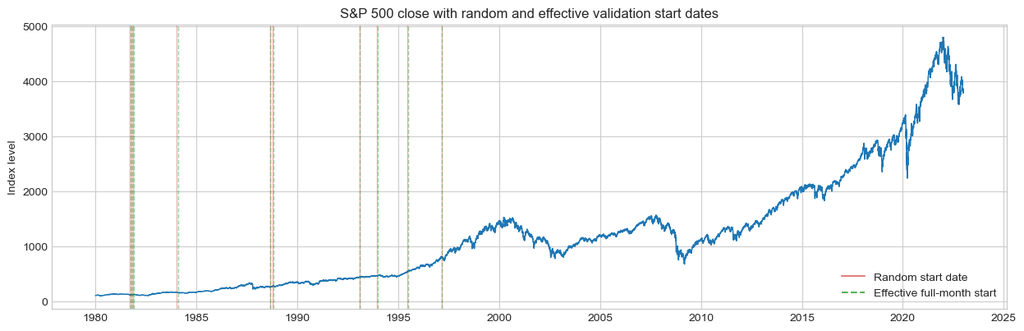

```python
def generate_random_start_dates(seed=CV_SEED, n=CV_FOLDS):
    all_dates = pd.date_range(CV_RANDOM_START_MIN, CV_RANDOM_START_MAX, freq="D")
    rng = np.random.default_rng(seed)
    picked = rng.choice(len(all_dates), size=n, replace=False)
    random_starts = pd.Series(all_dates[picked]).sort_values().reset_index(drop=True)
    effective_starts = random_starts.map(first_full_following_month)
    folds = pd.DataFrame(
        {
            "fold": range(1, n + 1),
            "random_start_date": random_starts,
            "effective_start_date": effective_starts,
        }
    )
    folds["years_to_end"] = (DATA_END - folds["effective_start_date"]).dt.days / 365.25
    assert (folds["years_to_end"] >= 20).all(), "Every fold should have at least 20 years of data."
    return folds


folds = generate_random_start_dates()
display(folds)

fig, ax = plt.subplots(figsize=(15, 4.5))
ax.plot(simulation.index, simulation["Close"], color="#1f77b4", lw=1.1)
for _, row in folds.iterrows():
    ax.axvline(row["random_start_date"], color="#d62728", alpha=0.35, lw=1)
    ax.axvline(row["effective_start_date"], color="#2ca02c", alpha=0.45, lw=1, linestyle="--")
ax.set_title("S&P 500 close with random and effective validation start dates")
ax.set_ylabel("Index level")
ax.plot([], [], color="#d62728", alpha=0.6, label="Random start date")
ax.plot([], [], color="#2ca02c", alpha=0.8, linestyle="--", label="Effective full-month start")
ax.legend()
plt.show()
```

```python
cv_results = []
for _, fold in folds.iterrows():
    fold_data = slice_for_backtest(simulation, fold["effective_start_date"], DATA_END)
    results, _ = run_all_strategies(fold_data)
    results = add_family_ranks(results)
    results["fold"] = fold["fold"]
    results["random_start_date"] = fold["random_start_date"]
    results["effective_start_date"] = fold["effective_start_date"]
    baseline_return = results.loc[results["strategy_key"].eq("day_01"), "return_multiple"].iloc[0]
    results["baseline_gap_multiple"] = results["return_multiple"] - baseline_return
    cv_results.append(results)

cv_results = pd.concat(cv_results, ignore_index=True)

assert cv_results.groupby(["fold", "family"])["total_budget"].nunique().max() == 1
assert cv_results["return_multiple"].dtype.kind in "fc"
assert cv_results["rank_in_family"].dtype.kind in "fc"

print(f"CV rows: {len(cv_results):,}")
display(cv_results.head())
```

```
CV rows: 490
```

|  | total_budget | total_invested | cash_remaining | final_value | return_multiple | num_buys | family | strategy_key | strategy_name | sort_order | week_number | weekday | return_pct | rank_in_family | rank_bucket | fold | random_start_date | effective_start_date | baseline_gap_multiple |
| --- | --- | --- | --- | --- | --- | --- | --- | --- | --- | --- | --- | --- | --- | --- | --- | --- | --- | --- | --- |
| 0 | 109587.84 | 109587.84 | 0.0 | 587013.5833 | 5.3566 | 495 | day_of_month | day_01 | Day 1 | 1 | NaN | NaN | 435.6558 | 1.0 | top_quartile | 1 | 1981-09-19 | 1981-10-01 | 0.0000 |
| 1 | 109587.84 | 109587.84 | 0.0 | 586292.3152 | 5.3500 | 495 | day_of_month | day_02 | Day 2 | 2 | NaN | NaN | 434.9976 | 7.0 | top_quartile | 1 | 1981-09-19 | 1981-10-01 | -0.0066 |
| 2 | 109587.84 | 109587.84 | 0.0 | 586126.2420 | 5.3485 | 495 | day_of_month | day_03 | Day 3 | 3 | NaN | NaN | 434.8461 | 10.0 | middle | 1 | 1981-09-19 | 1981-10-01 | -0.0081 |
| 3 | 109587.84 | 109587.84 | 0.0 | 586476.7734 | 5.3517 | 495 | day_of_month | day_04 | Day 4 | 4 | NaN | NaN | 435.1659 | 3.0 | top_quartile | 1 | 1981-09-19 | 1981-10-01 | -0.0049 |
| 4 | 109587.84 | 109587.84 | 0.0 | 586338.6718 | 5.3504 | 495 | day_of_month | day_05 | Day 5 | 5 | NaN | NaN | 435.0399 | 5.0 | top_quartile | 1 | 1981-09-19 | 1981-10-01 | -0.0062 |

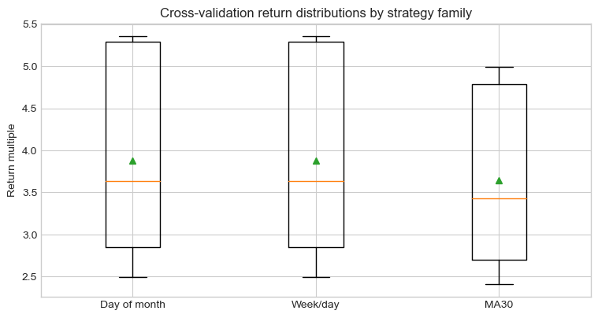

```python
fig, ax = plt.subplots(figsize=(9, 4.5))
family_order = ["day_of_month", "week_day", "moving_average"]
box_data = [cv_results.loc[cv_results["family"].eq(family), "return_multiple"] for family in family_order]
ax.boxplot(box_data, labels=["Day of month", "Week/day", "MA30"], showmeans=True)
ax.set_title("Cross-validation return distributions by strategy family")
ax.set_ylabel("Return multiple")
plt.show()
```

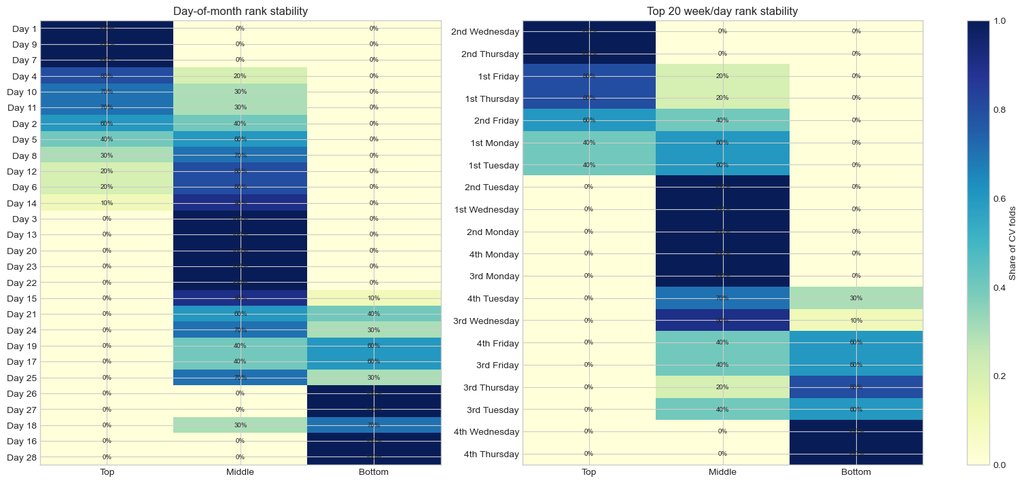

| strategy_name | top_quartile | middle | bottom_quartile | avg_rank |
| --- | --- | --- | --- | --- |
| Day 1 | 100% | 0% | 0% | 1.20 |
| Day 9 | 100% | 0% | 0% | 2.50 |
| Day 7 | 100% | 0% | 0% | 4.00 |
| Day 4 | 80% | 20% | 0% | 5.80 |
| Day 10 | 70% | 30% | 0% | 4.80 |
| Day 11 | 70% | 30% | 0% | 7.00 |
| Day 2 | 60% | 40% | 0% | 7.50 |
| Day 5 | 40% | 60% | 0% | 9.60 |
| Day 8 | 30% | 70% | 0% | 10.50 |
| Day 12 | 20% | 80% | 0% | 10.50 |

| strategy_name | top_quartile | middle | bottom_quartile | avg_rank |
| --- | --- | --- | --- | --- |
| 2nd Wednesday | 100% | 0% | 0% | 1.40 |
| 2nd Thursday | 100% | 0% | 0% | 3.60 |
| 1st Friday | 80% | 20% | 0% | 2.90 |
| 1st Thursday | 80% | 20% | 0% | 4.10 |
| 2nd Friday | 60% | 40% | 0% | 5.00 |
| 1st Monday | 40% | 60% | 0% | 5.50 |
| 1st Tuesday | 40% | 60% | 0% | 6.30 |
| 2nd Tuesday | 0% | 100% | 0% | 8.00 |
| 1st Wednesday | 0% | 100% | 0% | 9.50 |
| 2nd Monday | 0% | 100% | 0% | 10.70 |

```python
def bucket_frequency_table(cv, family):
    subset = cv.loc[cv["family"].eq(family)]
    counts = (
        subset.groupby(["strategy_name", "rank_bucket"])
        .size()
        .unstack(fill_value=0)
        .reindex(columns=["top_quartile", "middle", "bottom_quartile"], fill_value=0)
    )
    counts = counts / subset["fold"].nunique()
    avg_rank = subset.groupby("strategy_name")["rank_in_family"].mean().rename("avg_rank")
    return counts.join(avg_rank).sort_values(["top_quartile", "avg_rank"], ascending=[False, True])


day_stability = bucket_frequency_table(cv_results, "day_of_month")
week_stability = bucket_frequency_table(cv_results, "week_day")

fig, axes = plt.subplots(1, 2, figsize=(15, 7), constrained_layout=True)

day_heat = day_stability[["top_quartile", "middle", "bottom_quartile"]]
im0 = axes[0].imshow(day_heat.values, cmap="YlGnBu", aspect="auto", vmin=0, vmax=1)
axes[0].set_title("Day-of-month rank stability")
axes[0].set_xticks(range(3), ["Top", "Middle", "Bottom"])
axes[0].set_yticks(range(len(day_heat)), day_heat.index)
for i in range(day_heat.shape[0]):
    for j in range(day_heat.shape[1]):
        axes[0].text(j, i, f"{day_heat.iloc[i, j]:.0%}", ha="center", va="center", fontsize=7)

week_heat = week_stability.head(20)[["top_quartile", "middle", "bottom_quartile"]]
im1 = axes[1].imshow(week_heat.values, cmap="YlGnBu", aspect="auto", vmin=0, vmax=1)
axes[1].set_title("Top 20 week/day rank stability")
axes[1].set_xticks(range(3), ["Top", "Middle", "Bottom"])
axes[1].set_yticks(range(len(week_heat)), week_heat.index)
for i in range(week_heat.shape[0]):
    for j in range(week_heat.shape[1]):
        axes[1].text(j, i, f"{week_heat.iloc[i, j]:.0%}", ha="center", va="center", fontsize=7)

fig.colorbar(im1, ax=axes, label="Share of CV folds")
plt.show()

display(day_stability.head(10).style.format({"top_quartile": "{:.0%}", "middle": "{:.0%}", "bottom_quartile": "{:.0%}", "avg_rank": "{:.2f}"}))
display(week_stability.head(10).style.format({"top_quartile": "{:.0%}", "middle": "{:.0%}", "bottom_quartile": "{:.0%}", "avg_rank": "{:.2f}"}))
```

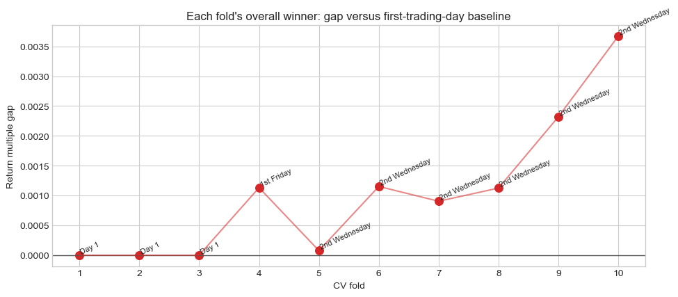

|  | fold | random_start_date | effective_start_date | family | strategy_name | return_multiple | baseline_gap_multiple |
| --- | --- | --- | --- | --- | --- | --- | --- |
| 0 | 1 | 1981-09-19 00:00:00 | 1981-10-01 00:00:00 | day_of_month | Day 1 | 5.3566x | +0.0000x |
| 49 | 2 | 1981-10-13 00:00:00 | 1981-11-01 00:00:00 | day_of_month | Day 1 | 5.3289x | +0.0000x |
| 98 | 3 | 1981-11-18 00:00:00 | 1981-12-01 00:00:00 | day_of_month | Day 1 | 5.3031x | +0.0000x |
| 179 | 4 | 1984-01-11 00:00:00 | 1984-02-01 00:00:00 | week_day | 1st Friday | 4.6381x | +0.0011x |
| 231 | 5 | 1988-08-27 00:00:00 | 1988-09-01 00:00:00 | week_day | 2nd Wednesday | 3.6567x | +0.0001x |
| 280 | 6 | 1988-10-08 00:00:00 | 1988-11-01 00:00:00 | week_day | 2nd Wednesday | 3.6262x | +0.0012x |
| 329 | 7 | 1993-01-29 00:00:00 | 1993-02-01 00:00:00 | week_day | 2nd Wednesday | 2.9780x | +0.0009x |
| 378 | 8 | 1993-12-10 00:00:00 | 1994-01-01 00:00:00 | week_day | 2nd Wednesday | 2.8584x | +0.0011x |
| 427 | 9 | 1995-06-18 00:00:00 | 1995-07-01 00:00:00 | week_day | 2nd Wednesday | 2.6562x | +0.0023x |
| 476 | 10 | 1997-02-28 00:00:00 | 1997-03-01 00:00:00 | week_day | 2nd Wednesday | 2.5037x | +0.0037x |

```python
fold_winners = (
    cv_results.sort_values(["fold", "return_multiple"], ascending=[True, False])
    .groupby("fold")
    .head(1)
    .copy()
)

fig, ax = plt.subplots(figsize=(11, 4.5))
ax.axhline(0, color="#555555", lw=1)
ax.scatter(fold_winners["fold"], fold_winners["baseline_gap_multiple"], color="#d62728", s=70)
ax.plot(fold_winners["fold"], fold_winners["baseline_gap_multiple"], color="#d62728", alpha=0.55)
for _, row in fold_winners.iterrows():
    ax.text(row["fold"], row["baseline_gap_multiple"], row["strategy_name"], fontsize=8, rotation=25, ha="left", va="bottom")
ax.set_title("Each fold's overall winner: gap versus first-trading-day baseline")
ax.set_xlabel("CV fold")
ax.set_ylabel("Return multiple gap")
ax.set_xticks(fold_winners["fold"])
plt.show()

display(
    fold_winners[
        ["fold", "random_start_date", "effective_start_date", "family", "strategy_name", "return_multiple", "baseline_gap_multiple"]
    ].style.format({"return_multiple": "{:.4f}x", "baseline_gap_multiple": "{:+.4f}x"})
)
```

```python
full_rank_lookup = full_results.set_index("strategy_key")["rank_in_family"].rename("full_period_rank")
cv_summary = (
    cv_results.groupby(["family", "strategy_key", "strategy_name"])
    .agg(
        avg_cv_rank=("rank_in_family", "mean"),
        top_quartile_frequency=("rank_bucket", lambda s: (s == "top_quartile").mean()),
        avg_baseline_gap=("baseline_gap_multiple", "mean"),
        avg_return_multiple=("return_multiple", "mean"),
        min_return_multiple=("return_multiple", "min"),
        max_return_multiple=("return_multiple", "max"),
    )
    .reset_index()
    .join(full_rank_lookup, on="strategy_key")
)

compact_summary = (
    cv_summary.sort_values(["top_quartile_frequency", "avg_cv_rank"], ascending=[False, True])
    .head(15)
    .copy()
)

display(
    compact_summary[
        [
            "family",
            "strategy_name",
            "full_period_rank",
            "avg_cv_rank",
            "top_quartile_frequency",
            "avg_baseline_gap",
            "avg_return_multiple",
            "min_return_multiple",
            "max_return_multiple",
        ]
    ].style.format(
        {
            "full_period_rank": "{:.0f}",
            "avg_cv_rank": "{:.2f}",
            "top_quartile_frequency": "{:.0%}",
            "avg_baseline_gap": "{:+.4f}x",
            "avg_return_multiple": "{:.4f}x",
            "min_return_multiple": "{:.4f}x",
            "max_return_multiple": "{:.4f}x",
        }
    )
)
```

|  | family | strategy_name | full_period_rank | avg_cv_rank | top_quartile_frequency | avg_baseline_gap | avg_return_multiple | min_return_multiple | max_return_multiple |
| --- | --- | --- | --- | --- | --- | --- | --- | --- | --- |
| 28 | moving_average | MA30 cross below | 1 | 1.00 | 100% | -0.2417x | 3.6478x | 2.4097x | 4.9928x |
| 0 | day_of_month | Day 1 | 1 | 1.20 | 100% | +0.0000x | 3.8895x | 2.5000x | 5.3566x |
| 36 | week_day | 2nd Wednesday | 3 | 1.40 | 100% | -0.0001x | 3.8894x | 2.5037x | 5.3526x |
| 8 | day_of_month | Day 9 | 4 | 2.50 | 100% | -0.0018x | 3.8877x | 2.5008x | 5.3509x |
| 37 | week_day | 2nd Thursday | 6 | 3.60 | 100% | -0.0021x | 3.8875x | 2.5007x | 5.3508x |
| 6 | day_of_month | Day 7 | 2 | 4.00 | 100% | -0.0022x | 3.8874x | 2.4992x | 5.3525x |
| 33 | week_day | 1st Friday | 1 | 2.90 | 80% | -0.0015x | 3.8880x | 2.4983x | 5.3530x |
| 32 | week_day | 1st Thursday | 4 | 4.10 | 80% | -0.0028x | 3.8868x | 2.4998x | 5.3498x |
| 3 | day_of_month | Day 4 | 5 | 5.80 | 80% | -0.0027x | 3.8868x | 2.4978x | 5.3517x |
| 9 | day_of_month | Day 10 | 9 | 4.80 | 70% | -0.0029x | 3.8867x | 2.5001x | 5.3492x |
| 10 | day_of_month | Day 11 | 11 | 7.00 | 70% | -0.0037x | 3.8859x | 2.4999x | 5.3479x |
| 38 | week_day | 2nd Friday | 8 | 5.00 | 60% | -0.0031x | 3.8864x | 2.5002x | 5.3489x |
| 1 | day_of_month | Day 2 | 6 | 7.50 | 60% | -0.0038x | 3.8857x | 2.4983x | 5.3500x |
| 29 | week_day | 1st Monday | 2 | 5.50 | 40% | -0.0030x | 3.8865x | 2.4978x | 5.3518x |
| 30 | week_day | 1st Tuesday | 7 | 6.30 | 40% | -0.0039x | 3.8856x | 2.5002x | 5.3481x |

## 6. Interpretation

```python
best_full_day = full_results.query("family == 'day_of_month'").sort_values("return_multiple", ascending=False).iloc[0]
best_full_week = full_results.query("family == 'week_day'").sort_values("return_multiple", ascending=False).iloc[0]
ma_full = full_results.query("strategy_key == 'ma30_cross_below'").iloc[0]

def stability_sentence(strategy_key):
    row = cv_summary.loc[cv_summary["strategy_key"].eq(strategy_key)].iloc[0]
    return (
        f"{row['strategy_name']}: full-period family rank {row['full_period_rank']:.0f}, "
        f"average CV rank {row['avg_cv_rank']:.2f}, top-quartile frequency {row['top_quartile_frequency']:.0%}, "
        f"average baseline gap {row['avg_baseline_gap']:+.4f}x."
    )


print("Full-period winners")
print(f"- Day-of-month: {best_full_day['strategy_name']} at {best_full_day['return_multiple']:.4f}x")
print(f"- Week/day: {best_full_week['strategy_name']} at {best_full_week['return_multiple']:.4f}x")
print(f"- MA30 cross-below: {ma_full['return_multiple']:.4f}x including carried cash")
print()
print("Start-date robustness for the full-period winners")
print("-", stability_sentence(best_full_day["strategy_key"]))
print("-", stability_sentence(best_full_week["strategy_key"]))
print("-", stability_sentence("ma30_cross_below"))
print()
print("Reading guide")
print("- If a full-period winner has low top-quartile frequency or a weak average CV rank, the result is probably start-date sensitive.")
print("- If return gaps are small relative to CV variation, the practical conclusion is that exact DCA timing is not very stable.")
print("- The MA30 strategy is evaluated as a cash-aware trigger strategy, so unused monthly budgets remain as cash in final value.")
```

```
Full-period winners
- Day-of-month: Day 1 at 5.8658x
- Week/day: 1st Friday at 5.8642x
- MA30 cross-below: 5.4787x including carried cash

Start-date robustness for the full-period winners
- Day 1: full-period family rank 1, average CV rank 1.20, top-quartile frequency 100%, average baseline gap +0.0000x.
- 1st Friday: full-period family rank 1, average CV rank 2.90, top-quartile frequency 80%, average baseline gap -0.0015x.
- MA30 cross below: full-period family rank 1, average CV rank 1.00, top-quartile frequency 100%, average baseline gap -0.2417x.

Reading guide
- If a full-period winner has low top-quartile frequency or a weak average CV rank, the result is probably start-date sensitive.
- If return gaps are small relative to CV variation, the practical conclusion is that exact DCA timing is not very stable.
- The MA30 strategy is evaluated as a cash-aware trigger strategy, so unused monthly budgets remain as cash in final value.
```